# COVID-19 cytokines and the hyperactive immune response: Synergism of TNF-α and IFN-γ in triggering inflammation, tissue damage, and death

Agustin

8/6/2021

El trabajo está basado en un paper en el cual utilizaron microarrays de la marca Affymetrix para comparar los perfiles de transcripción de macrófagos primarios derivados de la médula ósea (BMDM) de ratones Irf1 KO y WT que habían sido estimulados en cultivo con TNF-a, IFN-g o ambas citocinas simultáneamente. DOI: 10.1101/2020.10.29.361048

Los archivos que contien la información de cada una las muestras en formato .CEL fueron descargadas de la página: https://www.ncbi.nlm.nih.gov/geo/query/acc.cgi?acc=GSE160163

Posteriormente fueron almacenadas en la carpeta donde se encuentra alojado el proyecto R referente a este trabajo

```r
library("oligo")
```

Se leen los archivos .CEL descargados anteriormente del NCBI

```r
Data <- list.celfiles()
data_affy <- read.celfiles(Data)
```

```
## Platform design info loaded.
```

```
## Reading in : GSM4861695_RAJ001_1725387_ClariomSmouse.CEL
## Reading in : GSM4861696_RAJ002_1725388_ClariomSmouse.CEL
## Reading in : GSM4861697_RAJ003_1725389_ClariomSmouse.CEL
## Reading in : GSM4861698_RAJ004_1725390_ClariomSmouse.CEL
## Reading in : GSM4861699_RAJ005_1725391_ClariomSmouse.CEL
## Reading in : GSM4861700_RAJ006_1725392_ClariomSmouse.CEL
## Reading in : GSM4861701_RAJ009_1725395_ClariomSmouse.CEL
## Reading in : GSM4861702_RAJ010_1725396_ClariomSmouse.CEL
## Reading in : GSM4861703_RAJ013_1725399_ClariomSmouse.CEL
## Reading in : GSM4861704_RAJ014_1725400_ClariomSmouse.CEL
## Reading in : GSM4861706_RAJ015_1725401_ClariomSmouse.CEL
## Reading in : GSM4861708_RAJ016_1725402_ClariomSmouse.CEL
```

Gráficos caja y bigote e histograma con los datos sin normalizar

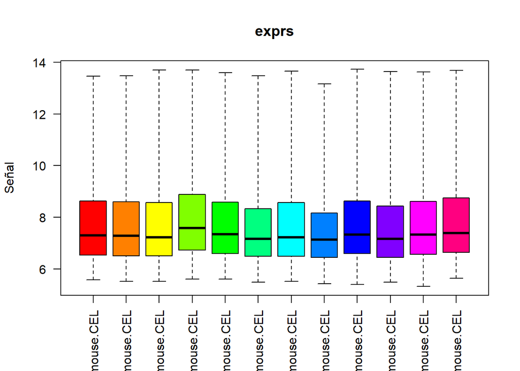

```r
boxplot(data_affy, col=rainbow(12), las=2, ylab="Señal")
```

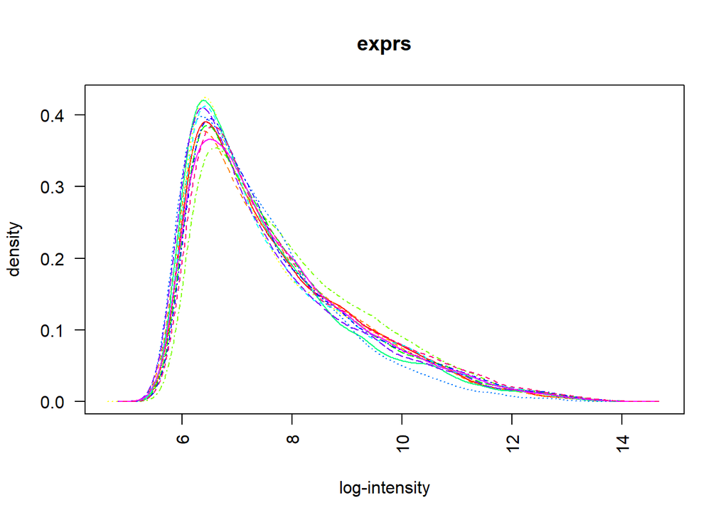

```r
hist(data_affy, col=rainbow(12), las=2)
```

Se normalizan los datos

```r
rma_affy <- oligo::rma(data_affy)
```

```
## Background correcting
## Normalizing
## Calculating Expression
```

Gráficos caja y bigote e histograma con los datos normalizados

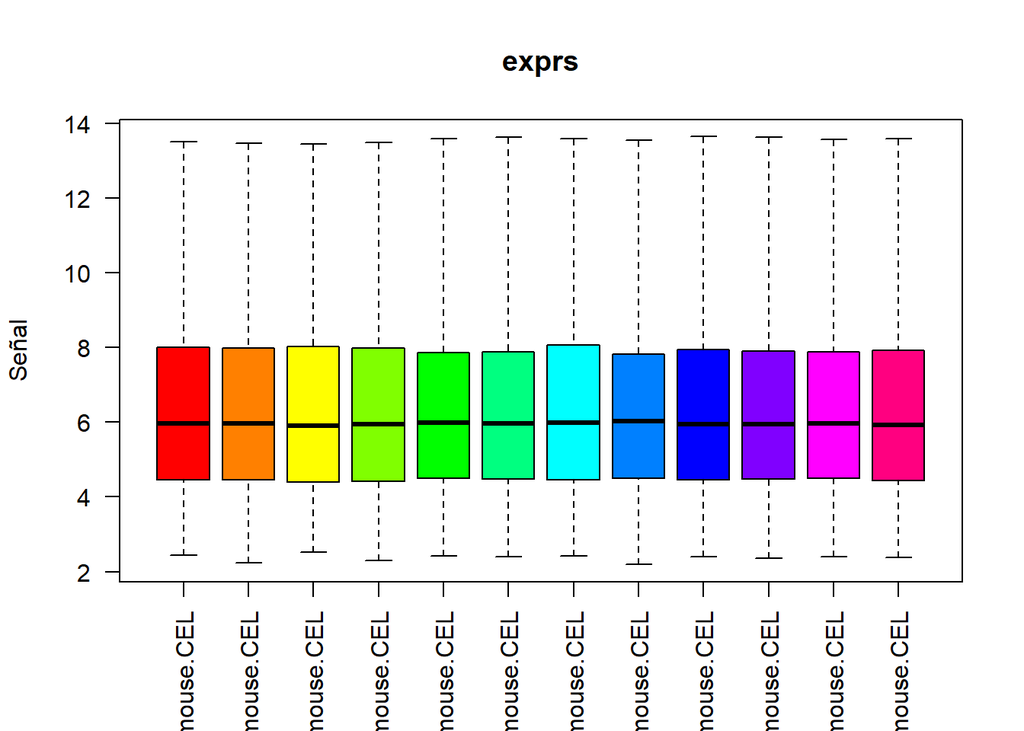

```r
boxplot(rma_affy, col=rainbow(12), las=2, ylab="Señal")
```

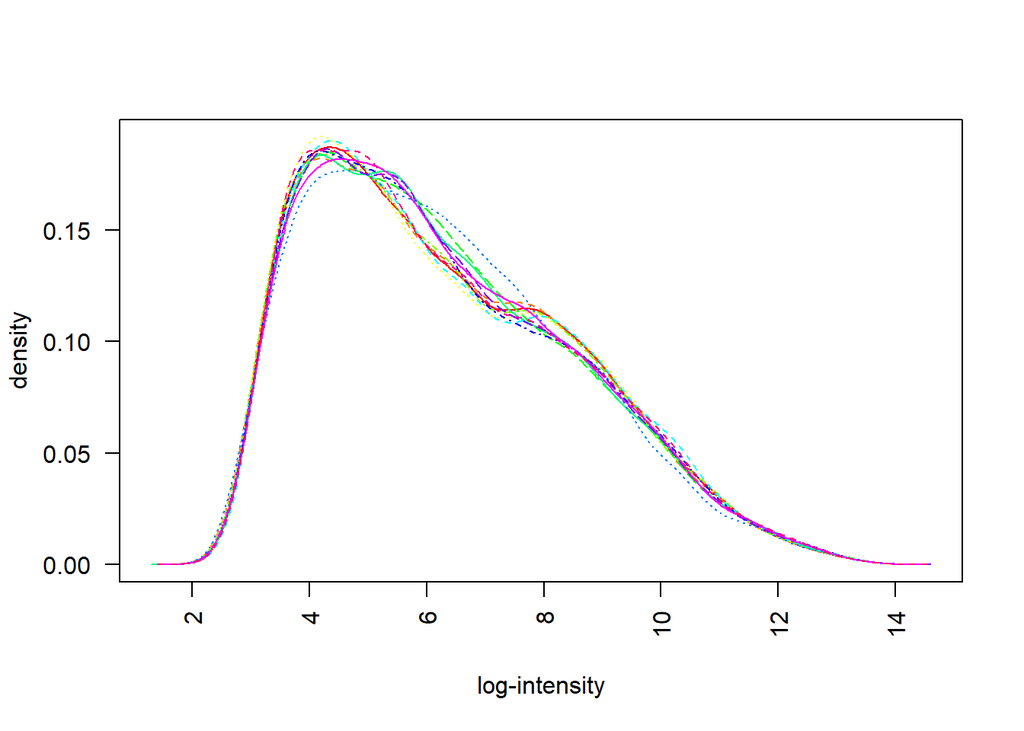

```r
hist(rma_affy, col=rainbow(12), las=2)
```

```r
expression_levels <- exprs(rma_affy)
```

```r
IDs_mouse <- c("WT_sin_estimular_1", "WT_sin_estimular_2", "IRF_KO_sin_estimular_1", "IRF_KO_sin_estimular_2", "WT_TNF-a_1", "WT_TNF-a_2", "WT_IFN-g_1", "WT_IFN-g_2", "WT_TNF-a_IFN-g_1", "WT_TNF-a_IFN-g_2", "IRF_KO_TNF-a_IFN-g_1", "IRF_KO_TNF-a_IFN-g_2")
colnames(expression_levels) <- IDs_mouse
```

Calculo el promedio de los controles y los tratamientos

```r
WT_sin_estimular <- (expression_levels[, IDs_mouse[1]] + expression_levels[, IDs_mouse[2]])/2
IRF_KO_sin_estimular <-(expression_levels[, IDs_mouse[3]] + expression_levels[, IDs_mouse[4]])/2
WT_TNFa <- (expression_levels[, IDs_mouse[5]] + expression_levels[, IDs_mouse[6]])/2
WT_IFNg <- (expression_levels[, IDs_mouse[7]] + expression_levels[, IDs_mouse[8]])/2
WT_TNFa_IFNg <-(expression_levels[, IDs_mouse[9]] + expression_levels[, IDs_mouse[10]])/2
IRF_KO_TNFa_IFNg <- (expression_levels[, IDs_mouse[11]] + expression_levels[, IDs_mouse[12]])/2

expression_average <- matrix(c(WT_sin_estimular, IRF_KO_sin_estimular, WT_TNFa, WT_IFNg, WT_TNFa_IFNg, IRF_KO_TNFa_IFNg), ncol = 6)

IDs_mouse_conditions <- c("WT_sin_estimular", "IRF_KO_sin_estimular", "WT_TNFa", "WT_IFNg", "WT_TNFa_IFNg", "IRF_KO_TNFa_IFNg")

colnames(expression_average) <- IDs_mouse_conditions
row.names(expression_average) <- names(WT_sin_estimular)
```

```r
library("ggplot2")

X11()

# Agrego el comando X11() ya que si ejecutaba la funcion ggplot sin el mismo, R crasheaba
# y se reiniciaba. Basado en comentarios de usuarios de Ubuntu, parece ser que es un error
# vinculado este SO. En windows no tuve problemas, con lo cual, si se corre en otro puede
# que no sea necesario utilizarlo.
```

En este trabajo, elegí 4 comparaciones para realizar: * WT sin estimular vs WT con agregado de TNFa * WT sin estimular vs WT con agregado de IFNg * WT sin estimular vs WT con agregado de TNFa e IFNg * IRF KO estimular vs IRF KO con agregado de TNFa e IFNg

Se muestran 4 gráficos de comparación de expresiones de cada uno

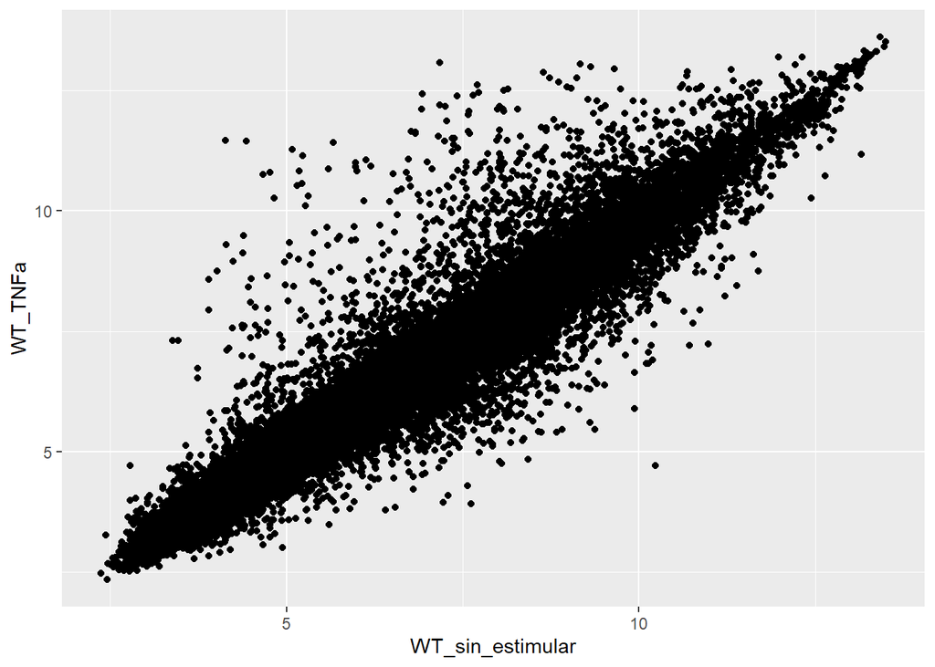

```r
sin_estimular_vs_TNF <- data.frame(expression_average[WT_sin_estimular],expression_average[WT_TNFa])
ggplot(data = sin_estimular_vs_TNF, aes (x = WT_sin_estimular, y = WT_TNFa)) + geom_point()
```

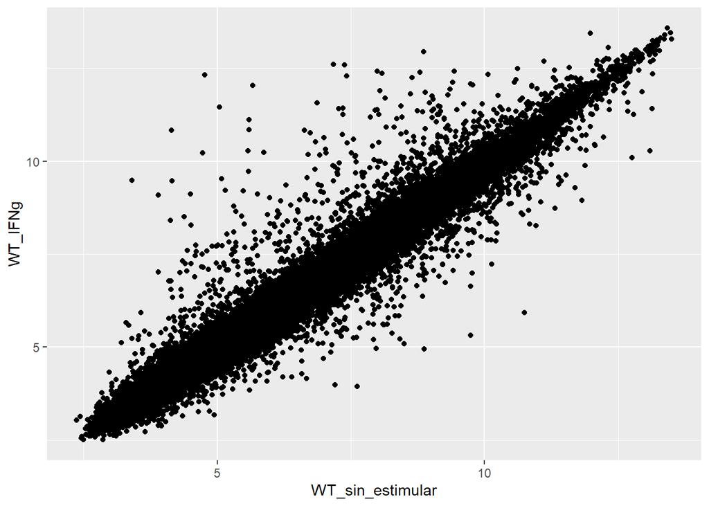

```r
sin_estimular_vs_IFN <- data.frame(expression_average[WT_sin_estimular],expression_average[WT_IFNg])
ggplot(data = sin_estimular_vs_IFN, aes (x = WT_sin_estimular, y = WT_IFNg)) + geom_point()
```

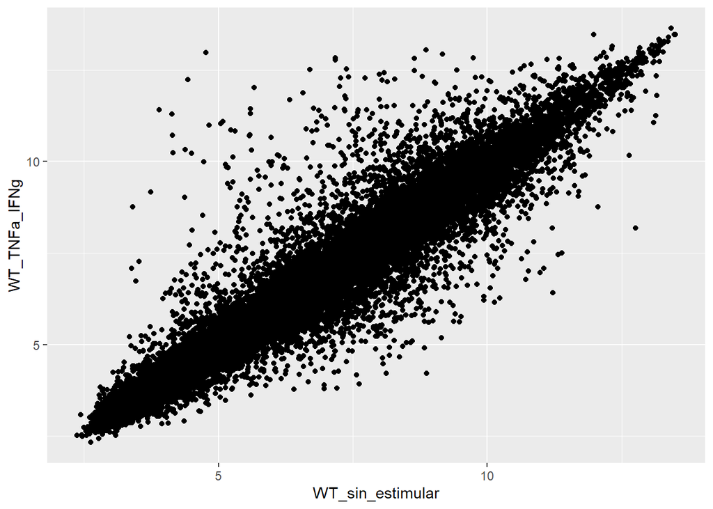

```r
sin_estimular_vs_TNF_IFN <- data.frame(expression_average[WT_sin_estimular],expression_average[WT_TNFa_IFNg])
ggplot(data = sin_estimular_vs_TNF_IFN, aes (x = WT_sin_estimular, y = WT_TNFa_IFNg)) + geom_point()
```

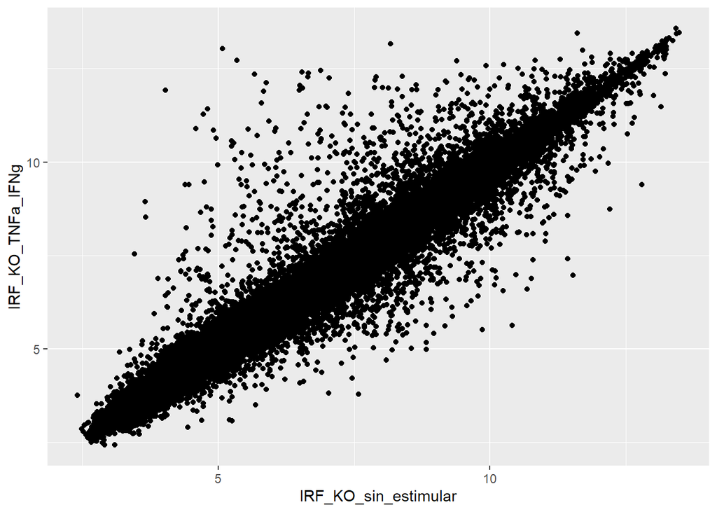

```r
IRF_KO_sin_estimular_vs_IRF_KO_TNFa_IFNg <- data.frame(expression_average[IRF_KO_sin_estimular],expression_average[IRF_KO_TNFa_IFNg])
ggplot(data = IRF_KO_sin_estimular_vs_IRF_KO_TNFa_IFNg, aes (x = IRF_KO_sin_estimular, y = IRF_KO_TNFa_IFNg)) + geom_point()
```

“limma” (Linear Models for Microarray Data) es un paquete de Bioconductor que permite ver que genes se expresan en mayor o menor medida en un microarray

```r
library(limma)
```

Para determinar los genes que se expresan de forma diferencial, en primer lugar se calcula el fold-change. Para esto se calcula el nivel de expresión media: se hace el promedio de las replicas para los controles (C) y para los tratamientos, en este caso con las citoquinas (T). Usualmente para cada gen, el fold-change = T/C , pero en microarryas los datos se encuentran transformados en log2, con lo cual el fold-change = T - C. Luego se debe fijar un umbral para ver que genes se expresan mas y cuales menos. * 1, 2 y 3 (para genes que se expresan x2, x4 y x8 respecto del control, respectivamente) * -1, -2 y -3 (para genes que se expresan 1/2, 1/4 y 1/8 respecto del control, respectivamente) Además, para eliminar los datos provenientes de ruidos de fondo, se tiene en consideracion aquellos genes que posean un qvalue < 0.01.

Primeramente, se genera una matriz asignandole un numero entero (1) a cada una de las muestras incluidas las replicas.

```r
gene_express <- model.matrix(~ -1+factor(c(1, 1, 2, 2, 3, 3, 4, 4, 5, 5, 6, 6)))
colnames(gene_express) <- IDs_mouse_conditions
```

Tratamiento - control * Comparacion = 0; la condicion no actua * Comparacion = -1; la condicion es el control * Comparacion = 1; la condicion es el tratamiento

```r
matriz_de_comparacion <- makeContrasts(WT_TNFa-WT_sin_estimular,
                                       WT_IFNg-WT_sin_estimular,
                                       WT_TNFa_IFNg-WT_sin_estimular,
                                       IRF_KO_TNFa_IFNg-IRF_KO_sin_estimular,
                                       levels = IDs_mouse_conditions)
```

Se calcula el fold-change para cada gen en cada una de las comparaciones especificadas

```r
regresion_lineal <- lmFit(expression_levels, gene_express)

comparaciones_fit <- contrasts.fit(regresion_lineal ,matriz_de_comparacion)
comparaciones_resultado <- eBayes(comparaciones_fit)
```

```r
library(clariomsmousetranscriptcluster.db)
library(annaffy)
```

Finalmente, se realiza la visualizacion grafica y la obtencion de los genes que se expresan mas y menos en cada condicion

1. WT sin estimular vs WT con TNFa

```r
WT_TNFa_vs_WT_sin_estimular <- topTable(comparaciones_resultado, number = dim(expression_levels)[1], coef = 1)


fold_change_WT_TNFa_vs_WT_sin_estimular <- WT_TNFa_vs_WT_sin_estimular[["logFC"]]
qvalue_WT_TNFa_vs_WT_sin_estimular <- WT_TNFa_vs_WT_sin_estimular[["adj.P.Val"]]
IDs_WT_TNFa_vs_WT_sin_estimular <- rownames(WT_TNFa_vs_WT_sin_estimular)


genes_sobrexpresados_WT_con_TNF <- IDs_WT_TNFa_vs_WT_sin_estimular[((fold_change_WT_TNFa_vs_WT_sin_estimular > 1) & qvalue_WT_TNFa_vs_WT_sin_estimular < 0.01)]
genes_reprimidos_WT_con_TNF <- IDs_WT_TNFa_vs_WT_sin_estimular[((fold_change_WT_TNFa_vs_WT_sin_estimular < -1) & qvalue_WT_TNFa_vs_WT_sin_estimular < 0.01)]


ID_mayor_gen_expresado_WT_TNF <- IDs_WT_TNFa_vs_WT_sin_estimular[((fold_change_WT_TNFa_vs_WT_sin_estimular == max(fold_change_WT_TNFa_vs_WT_sin_estimular)) & qvalue_WT_TNFa_vs_WT_sin_estimular < 0.01)]
ID_mayor_gen_expresado_WT_TNF
```

```
## [1] "TC0500002757.mm.2"
```

```r
ID_menor_gen_expresado_WT_TNF <- IDs_WT_TNFa_vs_WT_sin_estimular[((fold_change_WT_TNFa_vs_WT_sin_estimular == min(fold_change_WT_TNFa_vs_WT_sin_estimular)) & qvalue_WT_TNFa_vs_WT_sin_estimular < 0.01)]
ID_menor_gen_expresado_WT_TNF
```

```
## [1] "TC1700001173.mm.2"
```

```r
# Con este comando se obtienen datos referentes al gen mayor expresado WT con TNF
row_WT_TNF_act <- match(ID_mayor_gen_expresado_WT_TNF, IDs_WT_TNFa_vs_WT_sin_estimular)
activated_genes_WT_TNF <- aafTableAnn(genes_sobrexpresados_WT_con_TNF, "clariomsmousetranscriptcluster.db", aaf.handler())
activated_genes_WT_TNF[row_WT_TNF_act]
```

```
## An object of class "aafTable"
## Slot "probeids":
## [1] "TC0500002757.mm.2"
##
## Slot "table":
## $Probe
## An object of class "aafList"
## [[1]]
## An object of class "aafProbe"
## [1] "TC0500002757.mm.2"
##
##
## $Symbol
## An object of class "aafList"
## [[1]]
## [1] "Cxcl11"
## attr(,"class")
## [1] "aafSymbol"
##
##
## $Description
## An object of class "aafList"
## [[1]]
## [1] "chemokine (C-X-C motif) ligand 11"
## attr(,"class")
## [1] "aafDescription"
##
##
## $Chromosome
## An object of class "aafList"
## [[1]]
## [1] "5"
## attr(,"class")
## [1] "aafChromosome"
##
##
## $`Chromosome Location`
## An object of class "aafList"
## [[1]]
## An object of class "aafChromLoc"
```

[output cut: 97 more lines]

```
## @id     "04060"
## @name   "04060"
## @enzyme ""
##
## [[1]][[2]]
## An object of class "aafGOItem"
## @id     "04062"
## @name   "04062"
## @enzyme ""
##
## [[1]][[3]]
## An object of class "aafGOItem"
## @id     "04620"
## @name   "04620"
## @enzyme ""
```

```r
# Para mas informacion sobre los genes activados en esta situacion:
saveHTML(activated_genes_WT_TNF, file="genes sobrexpresados WT con TNF.html")

# Con este comando se obtienen datos referentes al gen mayor expresado WT sin estimular
row_WT_TNF_rep <- match(ID_mayor_gen_expresado_WT_TNF, IDs_WT_TNFa_vs_WT_sin_estimular)
repressed_genes_WT_TNF <- aafTableAnn(genes_reprimidos_WT_con_TNF, "clariomsmousetranscriptcluster.db", aaf.handler())
repressed_genes_WT_TNF[row_WT_TNF_rep]
```

```
## An object of class "aafTable"
## Slot "probeids":
## [1] "TC0300001137.mm.2"
##
## Slot "table":
## $Probe
## An object of class "aafList"
## [[1]]
## An object of class "aafProbe"
## [1] "TC0300001137.mm.2"
##
##
## $Symbol
## An object of class "aafList"
## [[1]]
## [1] "Sort1"
## attr(,"class")
## [1] "aafSymbol"
##
##
## $Description
## An object of class "aafList"
## [[1]]
## [1] "sortilin 1"
## attr(,"class")
## [1] "aafDescription"
##
##
## $Chromosome
## An object of class "aafList"
## [[1]]
## [1] "3"
## attr(,"class")
## [1] "aafChromosome"
##
##
## $`Chromosome Location`
## An object of class "aafList"
## [[1]]
## An object of class "aafChromLoc"
```

[output cut: 472 more lines]

```
## $Pathway
## An object of class "aafList"
## [[1]]
## An object of class "aafPathway"
## [[1]][[1]]
## An object of class "aafGOItem"
## @id     "04142"
## @name   "04142"
## @enzyme ""
##
## [[1]][[2]]
## An object of class "aafGOItem"
## @id     "04722"
## @name   "04722"
## @enzyme ""
```

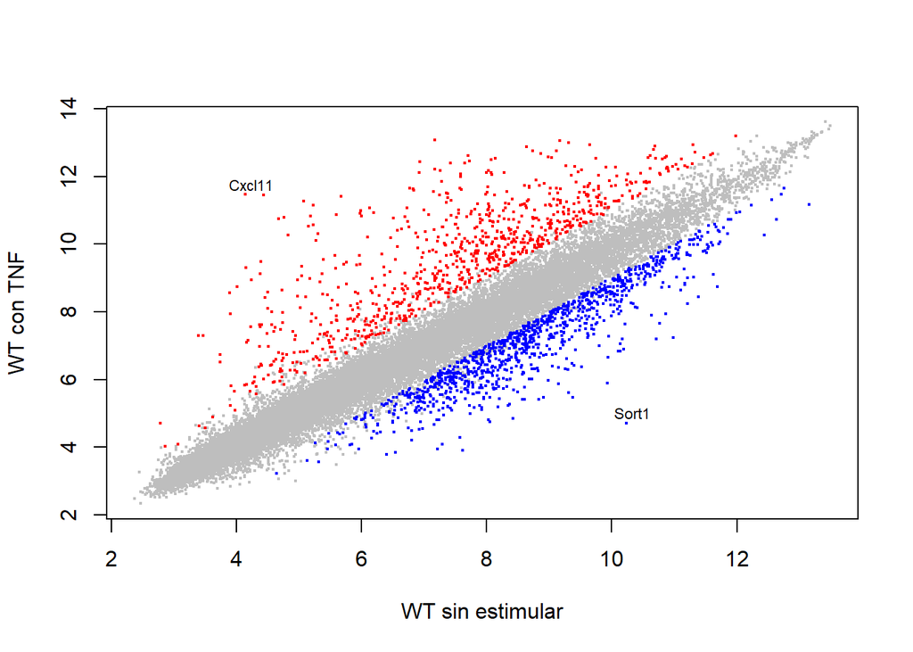

```r
# Para mas informacion sobre los genes activados en esta situacion:
saveHTML(repressed_genes_WT_TNF, file="genes reprimidos WT con TNF.html")

# Grafica
plot(WT_sin_estimular,WT_TNFa ,pch=19,cex=0.3,col="grey",xlab="WT sin estimular",ylab="WT con TNF")


points(WT_sin_estimular[genes_sobrexpresados_WT_con_TNF],WT_TNFa[genes_sobrexpresados_WT_con_TNF],pch=19,cex=0.3,col="red")
mayor_WT_TNF_symbol <- activated_genes_WT_TNF[row_WT_TNF_act]$Symbol[[1]][1]
text(WT_sin_estimular[ID_mayor_gen_expresado_WT_TNF]+ 0.1,WT_TNFa[ID_mayor_gen_expresado_WT_TNF]+0.3,mayor_WT_TNF_symbol, col="black", cex=0.7)

points(WT_sin_estimular[genes_reprimidos_WT_con_TNF],WT_TNFa[genes_reprimidos_WT_con_TNF],pch=19,cex=0.3, col="blue")
menor_WT_TNF_symbol <- repressed_genes_WT_TNF[row_WT_TNF_rep]$Symbol[[1]][1]
text(WT_sin_estimular[ID_menor_gen_expresado_WT_TNF]+ 0.1,WT_TNFa[ID_menor_gen_expresado_WT_TNF]+0.3,menor_WT_TNF_symbol, col="black", cex=0.7)
```

2. WT sin estimular vs WT con IFNg

```r
WT_IFNg_vs_WT_sin_estimular <- topTable(comparaciones_resultado, number = dim(expression_levels)[1], coef = 2)


fold_change_WT_IFNg_vs_WT_sin_estimular <- WT_IFNg_vs_WT_sin_estimular[["logFC"]]
qvalue_WT_IFNg_vs_WT_sin_estimular <- WT_IFNg_vs_WT_sin_estimular[["adj.P.Val"]]
IDs_WT_WT_IFNg_vs_WT_sin_estimular <- rownames(WT_IFNg_vs_WT_sin_estimular)


genes_sobrexpresados_WT_con_IFN <- IDs_WT_WT_IFNg_vs_WT_sin_estimular[((fold_change_WT_IFNg_vs_WT_sin_estimular > 1) & qvalue_WT_IFNg_vs_WT_sin_estimular < 0.01)]
genes_reprimidos_WT_con_IFN <- IDs_WT_WT_IFNg_vs_WT_sin_estimular[((fold_change_WT_IFNg_vs_WT_sin_estimular < -1) & qvalue_WT_IFNg_vs_WT_sin_estimular < 0.01)]


ID_mayor_gen_expresado_WT_IFN <- IDs_WT_WT_IFNg_vs_WT_sin_estimular[((fold_change_WT_IFNg_vs_WT_sin_estimular == max(fold_change_WT_IFNg_vs_WT_sin_estimular)) & qvalue_WT_IFNg_vs_WT_sin_estimular < 0.01)]
ID_mayor_gen_expresado_WT_IFN
```

```
## [1] "TC0500002755.mm.2"
```

```r
ID_menor_gen_expresado_WT_IFN <- IDs_WT_WT_IFNg_vs_WT_sin_estimular[((fold_change_WT_IFNg_vs_WT_sin_estimular == min(fold_change_WT_IFNg_vs_WT_sin_estimular)) & qvalue_WT_IFNg_vs_WT_sin_estimular < 0.01)]
ID_menor_gen_expresado_WT_IFN
```

```
## [1] "TC0300001639.mm.2"
```

```r
# Con este comando se obtienen datos referentes al gen mayor expresado WT con IFN
row_WT_IFN_act <- match(ID_mayor_gen_expresado_WT_IFN, IDs_WT_WT_IFNg_vs_WT_sin_estimular)
activated_genes_WT_IFN <- aafTableAnn(genes_sobrexpresados_WT_con_IFN, "clariomsmousetranscriptcluster.db", aaf.handler())
activated_genes_WT_IFN[row_WT_IFN_act]
```

```
## An object of class "aafTable"
## Slot "probeids":
## [1] "TC0500002755.mm.2"
##
## Slot "table":
## $Probe
## An object of class "aafList"
## [[1]]
## An object of class "aafProbe"
## [1] "TC0500002755.mm.2"
##
##
## $Symbol
## An object of class "aafList"
## [[1]]
## [1] "Cxcl9"
## attr(,"class")
## [1] "aafSymbol"
##
##
## $Description
## An object of class "aafList"
## [[1]]
## [1] "chemokine (C-X-C motif) ligand 9"
## attr(,"class")
## [1] "aafDescription"
##
##
## $Chromosome
## An object of class "aafList"
## [[1]]
## [1] "5"
## attr(,"class")
## [1] "aafChromosome"
##
##
## $`Chromosome Location`
## An object of class "aafList"
## [[1]]
## An object of class "aafChromLoc"
```

[output cut: 184 more lines]

```
## @id     "04060"
## @name   "04060"
## @enzyme ""
##
## [[1]][[2]]
## An object of class "aafGOItem"
## @id     "04062"
## @name   "04062"
## @enzyme ""
##
## [[1]][[3]]
## An object of class "aafGOItem"
## @id     "04620"
## @name   "04620"
## @enzyme ""
```

```r
# Para mas informacion sobre los genes activados en esta situacion:
saveHTML(activated_genes_WT_IFN, file="genes sobrexpresados WT con IFN.html")


# Con este comando se obtienen datos referentes al gen mayor expresado WT sin estimular
row_WT_IFN_rep <- match(ID_mayor_gen_expresado_WT_IFN, IDs_WT_WT_IFNg_vs_WT_sin_estimular)
repressed_genes_WT_IFN <- aafTableAnn(genes_reprimidos_WT_con_IFN, "clariomsmousetranscriptcluster.db", aaf.handler())
repressed_genes_WT_IFN[row_WT_TNF_rep]
```

```
## An object of class "aafTable"
## Slot "probeids":
## [1] "TC0900001673.mm.2"
##
## Slot "table":
## $Probe
## An object of class "aafList"
## [[1]]
## An object of class "aafProbe"
## [1] "TC0900001673.mm.2"
##
##
## $Symbol
## An object of class "aafList"
## [[1]]
## [1] "Ccr3"
## attr(,"class")
## [1] "aafSymbol"
##
##
## $Description
## An object of class "aafList"
## [[1]]
## [1] "chemokine (C-C motif) receptor 3"
## attr(,"class")
## [1] "aafDescription"
##
##
## $Chromosome
## An object of class "aafList"
## [[1]]
## [1] "9"
## attr(,"class")
## [1] "aafChromosome"
##
##
## $`Chromosome Location`
## An object of class "aafList"
## [[1]]
## An object of class "aafChromLoc"
```

[output cut: 243 more lines]

```
## $Pathway
## An object of class "aafList"
## [[1]]
## An object of class "aafPathway"
## [[1]][[1]]
## An object of class "aafGOItem"
## @id     "04060"
## @name   "04060"
## @enzyme ""
##
## [[1]][[2]]
## An object of class "aafGOItem"
## @id     "04062"
## @name   "04062"
## @enzyme ""
```

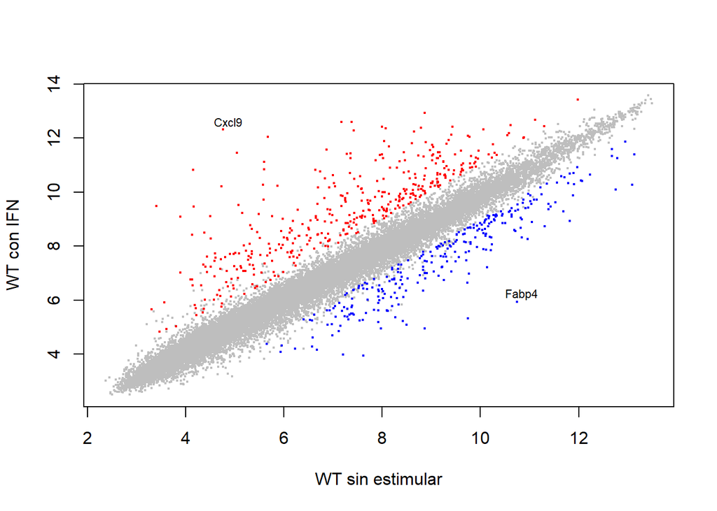

```r
# Para mas informacion sobre los genes reprimidos en esta situacion:
saveHTML(repressed_genes_WT_IFN, file="genes reprimidos WT con IFN.html")


# Grafica
plot(WT_sin_estimular,WT_IFNg ,pch=19,cex=0.3,col="grey",xlab="WT sin estimular",ylab="WT con IFN")

points(WT_sin_estimular[genes_sobrexpresados_WT_con_IFN],WT_IFNg[genes_sobrexpresados_WT_con_IFN],pch=19,cex=0.3,col="red")
mayor_WT_IFN_symbol <- activated_genes_WT_IFN[row_WT_IFN_act]$Symbol[[1]][1]
text(WT_sin_estimular[ID_mayor_gen_expresado_WT_IFN]+ 0.1,WT_IFNg[ID_mayor_gen_expresado_WT_IFN]+0.3,mayor_WT_IFN_symbol, col="black", cex=0.7)


points(WT_sin_estimular[genes_reprimidos_WT_con_IFN],WT_IFNg[genes_reprimidos_WT_con_IFN],pch=19,cex=0.3, col="blue")
menor_WT_IFN_symbol <- repressed_genes_WT_IFN[row_WT_IFN_rep]$Symbol[[1]][1]
text(WT_sin_estimular[ID_menor_gen_expresado_WT_IFN]+ 0.1,WT_IFNg[ID_menor_gen_expresado_WT_IFN]+0.3,menor_WT_IFN_symbol, col="black", cex=0.7)
```

3. WT sin estimular vs WT con TNFa y IFNg

```r
WT_TNFa_IFNg_vs_WT_sin_estimular <- topTable(comparaciones_resultado, number = dim(expression_levels)[1], coef = 3)


fold_change_WT_TNFa_IFNg_vs_WT_sin_estimular <- WT_TNFa_IFNg_vs_WT_sin_estimular[["logFC"]]
qvalue_WT_TNFa_IFNg_vs_WT_sin_estimular <- WT_TNFa_IFNg_vs_WT_sin_estimular[["adj.P.Val"]]
IDs_WT_TNFa_IFNg_vs_WT_sin_estimular <- rownames(WT_TNFa_IFNg_vs_WT_sin_estimular)


genes_sobrexpresados_WT_con_IFN_TNF <- IDs_WT_TNFa_IFNg_vs_WT_sin_estimular[((fold_change_WT_TNFa_IFNg_vs_WT_sin_estimular > 1) & qvalue_WT_TNFa_IFNg_vs_WT_sin_estimular < 0.01)]
genes_reprimidos_WT_con_IFN_TNF <- IDs_WT_TNFa_IFNg_vs_WT_sin_estimular[((fold_change_WT_TNFa_IFNg_vs_WT_sin_estimular < -1) & qvalue_WT_TNFa_IFNg_vs_WT_sin_estimular < 0.01)]


ID_mayor_gen_expresado_WT_IFN_TNF <- IDs_WT_TNFa_IFNg_vs_WT_sin_estimular[((fold_change_WT_TNFa_IFNg_vs_WT_sin_estimular == max(fold_change_WT_TNFa_IFNg_vs_WT_sin_estimular)) & qvalue_WT_TNFa_IFNg_vs_WT_sin_estimular < 0.01)]
ID_mayor_gen_expresado_WT_IFN_TNF
```

```
## [1] "TC0500002755.mm.2"
```

```r
ID_menor_gen_expresado_WT_IFN_TNF <- IDs_WT_TNFa_IFNg_vs_WT_sin_estimular[((fold_change_WT_TNFa_IFNg_vs_WT_sin_estimular == min(fold_change_WT_TNFa_IFNg_vs_WT_sin_estimular)) & qvalue_WT_TNFa_IFNg_vs_WT_sin_estimular < 0.01)]
ID_menor_gen_expresado_WT_IFN_TNF
```

```
## [1] "TC0200000245.mm.2"
```

```r
# Con este comando se obtienen datos referentes al gen mayor expresado WT con IFN
row_WT_IFN_TNF_act <- match(ID_mayor_gen_expresado_WT_IFN_TNF, IDs_WT_TNFa_IFNg_vs_WT_sin_estimular)
activated_genes_WT_IFN_TNF <- aafTableAnn(genes_sobrexpresados_WT_con_IFN_TNF, "clariomsmousetranscriptcluster.db", aaf.handler())
activated_genes_WT_IFN[row_WT_IFN_TNF_act]
```

```
## An object of class "aafTable"
## Slot "probeids":
## [1] "TC0500002755.mm.2"
##
## Slot "table":
## $Probe
## An object of class "aafList"
## [[1]]
## An object of class "aafProbe"
## [1] "TC0500002755.mm.2"
##
##
## $Symbol
## An object of class "aafList"
## [[1]]
## [1] "Cxcl9"
## attr(,"class")
## [1] "aafSymbol"
##
##
## $Description
## An object of class "aafList"
## [[1]]
## [1] "chemokine (C-X-C motif) ligand 9"
## attr(,"class")
## [1] "aafDescription"
##
##
## $Chromosome
## An object of class "aafList"
## [[1]]
## [1] "5"
## attr(,"class")
## [1] "aafChromosome"
##
##
## $`Chromosome Location`
## An object of class "aafList"
## [[1]]
## An object of class "aafChromLoc"
```

[output cut: 184 more lines]

```
## @id     "04060"
## @name   "04060"
## @enzyme ""
##
## [[1]][[2]]
## An object of class "aafGOItem"
## @id     "04062"
## @name   "04062"
## @enzyme ""
##
## [[1]][[3]]
## An object of class "aafGOItem"
## @id     "04620"
## @name   "04620"
## @enzyme ""
```

```r
# Para mas informacion sobre los genes activados en esta situacion:
saveHTML(activated_genes_WT_IFN_TNF, file="genes sobrexpresados WT con IFN y TNF.html")


# Con este comando se obtienen datos referentes al gen mayor expresado WT sin estimular
row_WT_IFN_TNF_rep <- match(ID_mayor_gen_expresado_WT_IFN_TNF, IDs_WT_TNFa_IFNg_vs_WT_sin_estimular)
repressed_genes_WT_IFN_TNF <- aafTableAnn(genes_reprimidos_WT_con_IFN_TNF, "clariomsmousetranscriptcluster.db", aaf.handler())
repressed_genes_WT_IFN_TNF[row_WT_TNF_rep]
```

```
## An object of class "aafTable"
## Slot "probeids":
## [1] "TC1400001676.mm.2"
##
## Slot "table":
## $Probe
## An object of class "aafList"
## [[1]]
## An object of class "aafProbe"
## [1] "TC1400001676.mm.2"
##
##
## $Symbol
## An object of class "aafList"
## [[1]]
## [1] "Sh3bp5"
## attr(,"class")
## [1] "aafSymbol"
##
##
## $Description
## An object of class "aafList"
## [[1]]
## [1] "SH3-domain binding protein 5 (BTK-associated)"
## attr(,"class")
## [1] "aafDescription"
##
##
## $Chromosome
## An object of class "aafList"
## [[1]]
## [1] "14"
## attr(,"class")
## [1] "aafChromosome"
##
##
## $`Chromosome Location`
## An object of class "aafList"
## [[1]]
## An object of class "aafChromLoc"
```

[output cut: 136 more lines]

```
##
## [[1]][[16]]
## An object of class "aafGOItem"
## @id   "GO:0061099"
## @name "negative regulation of protein tyrosine kinase activity"
## @type "Biological Process"
## @evid "IBA"
##
##
##
## $Pathway
## An object of class "aafList"
## [[1]]
## An object of class "aafPathway"
## list()
```

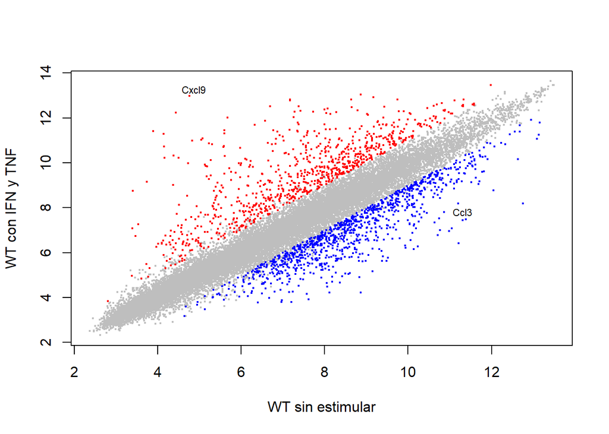

```r
# Para mas informacion sobre los genes reprimidos en esta situacion:
saveHTML(repressed_genes_WT_IFN_TNF, file="genes reprimidos WT con IFN y TNF.html")


# Grafica
plot(WT_sin_estimular,WT_TNFa_IFNg ,pch=19,cex=0.3,col="grey",xlab="WT sin estimular",ylab="WT con IFN y TNF")

points(WT_sin_estimular[genes_sobrexpresados_WT_con_IFN_TNF],WT_TNFa_IFNg[genes_sobrexpresados_WT_con_IFN_TNF],pch=19,cex=0.3,col="red")
mayor_WT_TNFa_IFNg_symbol <- activated_genes_WT_IFN_TNF[row_WT_IFN_TNF_act]$Symbol[[1]][1]
text(WT_sin_estimular[ID_mayor_gen_expresado_WT_IFN_TNF]+ 0.1,WT_TNFa_IFNg[ID_mayor_gen_expresado_WT_IFN_TNF]+0.3,mayor_WT_TNFa_IFNg_symbol, col="black", cex=0.7)


points(WT_sin_estimular[genes_reprimidos_WT_con_IFN_TNF],WT_TNFa_IFNg[genes_reprimidos_WT_con_IFN_TNF],pch=19,cex=0.3,col="blue")
menor_WT_TNFa_IFNg_symbol <- repressed_genes_WT_IFN_TNF[row_WT_IFN_TNF_rep]$Symbol[[1]][1]
text(WT_sin_estimular[ID_menor_gen_expresado_WT_IFN_TNF]+ 0.1,WT_TNFa_IFNg[ID_menor_gen_expresado_WT_IFN]+0.3,menor_WT_TNFa_IFNg_symbol, col="black", cex=0.7)
```

4. KO IRF sin estimular vs KO IRF con TNF y IFNg

```r
IRF_KO_TNFa_IFNg_vs_IRF_KO_sin_estimular <- topTable(comparaciones_resultado, number = dim(expression_levels)[1], coef = 4)


fold_change_IRF_KO_TNFa_IFNg_vs_IRF_KO_sin_estimular <- IRF_KO_TNFa_IFNg_vs_IRF_KO_sin_estimular[["logFC"]]
qvalue_IRF_KO_TNFa_IFNg_vs_IRF_KO_sin_estimular <- IRF_KO_TNFa_IFNg_vs_IRF_KO_sin_estimular[["adj.P.Val"]]
IDs_IRF_KO_TNFa_IFNg_vs_IRF_KO_sin_estimular <- rownames(IRF_KO_TNFa_IFNg_vs_IRF_KO_sin_estimular)


genes_sobrexpresados_IRF_con_IFN_TNF <- IDs_IRF_KO_TNFa_IFNg_vs_IRF_KO_sin_estimular[((fold_change_IRF_KO_TNFa_IFNg_vs_IRF_KO_sin_estimular > 1) & qvalue_IRF_KO_TNFa_IFNg_vs_IRF_KO_sin_estimular < 0.01)]
genes_reprimidos_IRF_con_IFN_TNF <- IDs_IRF_KO_TNFa_IFNg_vs_IRF_KO_sin_estimular[((fold_change_IRF_KO_TNFa_IFNg_vs_IRF_KO_sin_estimular < -1) & qvalue_IRF_KO_TNFa_IFNg_vs_IRF_KO_sin_estimular < 0.01)]


ID_mayor_gen_expresado_IRF_con_IFN_TNF <- IDs_IRF_KO_TNFa_IFNg_vs_IRF_KO_sin_estimular[((fold_change_IRF_KO_TNFa_IFNg_vs_IRF_KO_sin_estimular == max(fold_change_IRF_KO_TNFa_IFNg_vs_IRF_KO_sin_estimular)) & qvalue_IRF_KO_TNFa_IFNg_vs_IRF_KO_sin_estimular < 0.01)]
ID_mayor_gen_expresado_IRF_con_IFN_TNF
```

```
## [1] "TC0500002755.mm.2"
```

```r
ID_menor_gen_expresado_IRF_con_IFN_TNF<- IDs_IRF_KO_TNFa_IFNg_vs_IRF_KO_sin_estimular[((fold_change_IRF_KO_TNFa_IFNg_vs_IRF_KO_sin_estimular == min(fold_change_IRF_KO_TNFa_IFNg_vs_IRF_KO_sin_estimular)) & qvalue_IRF_KO_TNFa_IFNg_vs_IRF_KO_sin_estimular < 0.01)]
ID_menor_gen_expresado_IRF_con_IFN_TNF
```

```
## [1] "TC1700001173.mm.2"
```

```r
# Con este comando se obtienen datos referentes al gen mayor expresado WT con IFN
row_IRF_con_IFN_TNF_act <- match(ID_mayor_gen_expresado_IRF_con_IFN_TNF, IDs_IRF_KO_TNFa_IFNg_vs_IRF_KO_sin_estimular)
activated_genes_IRF_con_IFN_TNF<- aafTableAnn(genes_sobrexpresados_IRF_con_IFN_TNF, "clariomsmousetranscriptcluster.db", aaf.handler())
activated_genes_IRF_con_IFN_TNF[row_IRF_con_IFN_TNF_act]
```

```
## An object of class "aafTable"
## Slot "probeids":
## [1] "TC0500002755.mm.2"
##
## Slot "table":
## $Probe
## An object of class "aafList"
## [[1]]
## An object of class "aafProbe"
## [1] "TC0500002755.mm.2"
##
##
## $Symbol
## An object of class "aafList"
## [[1]]
## [1] "Cxcl9"
## attr(,"class")
## [1] "aafSymbol"
##
##
## $Description
## An object of class "aafList"
## [[1]]
## [1] "chemokine (C-X-C motif) ligand 9"
## attr(,"class")
## [1] "aafDescription"
##
##
## $Chromosome
## An object of class "aafList"
## [[1]]
## [1] "5"
## attr(,"class")
## [1] "aafChromosome"
##
##
## $`Chromosome Location`
## An object of class "aafList"
## [[1]]
## An object of class "aafChromLoc"
```

[output cut: 184 more lines]

```
## @id     "04060"
## @name   "04060"
## @enzyme ""
##
## [[1]][[2]]
## An object of class "aafGOItem"
## @id     "04062"
## @name   "04062"
## @enzyme ""
##
## [[1]][[3]]
## An object of class "aafGOItem"
## @id     "04620"
## @name   "04620"
## @enzyme ""
```

```r
# Para mas informacion sobre los genes activados en esta situacion:
saveHTML(activated_genes_IRF_con_IFN_TNF, file="genes sobrexpresados IRF con IFN y TNF.html")


# Con este comando se obtienen datos referentes al gen mayor expresado WT sin estimular
row_IRF_con_IFN_TNF_rep <-  match(ID_mayor_gen_expresado_IRF_con_IFN_TNF, IDs_IRF_KO_TNFa_IFNg_vs_IRF_KO_sin_estimular)
repressed_genes_IRF_con_IFN_TNF<- aafTableAnn(genes_reprimidos_IRF_con_IFN_TNF, "clariomsmousetranscriptcluster.db", aaf.handler())
repressed_genes_IRF_con_IFN_TNF[row_IRF_con_IFN_TNF_rep]
```

```
## An object of class "aafTable"
## Slot "probeids":
## [1] "TC0100002285.mm.2"
##
## Slot "table":
## $Probe
## An object of class "aafList"
## [[1]]
## An object of class "aafProbe"
## [1] "TC0100002285.mm.2"
##
##
## $Symbol
## An object of class "aafList"
## [[1]]
## [1] "Slc40a1"
## attr(,"class")
## [1] "aafSymbol"
##
##
## $Description
## An object of class "aafList"
## [[1]]
## [1] "solute carrier family 40 (iron-regulated transporter), member 1"
## attr(,"class")
## [1] "aafDescription"
##
##
## $Chromosome
## An object of class "aafList"
## [[1]]
## [1] "1"
## attr(,"class")
## [1] "aafChromosome"
##
##
## $`Chromosome Location`
## An object of class "aafList"
## [[1]]
## An object of class "aafChromLoc"
```

[output cut: 290 more lines]

```
##
## [[1]][[36]]
## An object of class "aafGOItem"
## @id   "GO:1903988"
## @name "iron ion export across plasma membrane"
## @type "Biological Process"
## @evid "IDA"
##
##
##
## $Pathway
## An object of class "aafList"
## [[1]]
## An object of class "aafPathway"
## list()
```

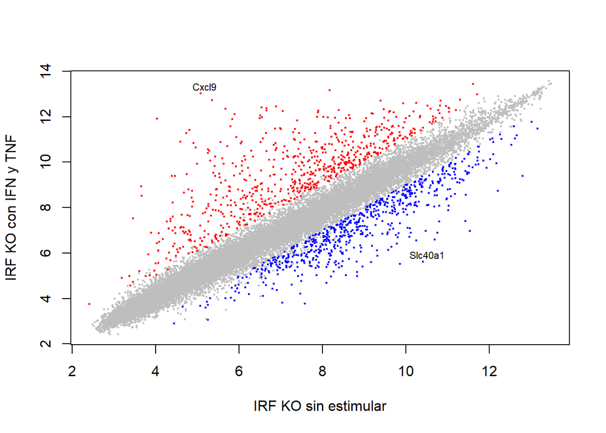

```r
# Para mas informacion sobre los genes reprimidos en esta situacion:
saveHTML(repressed_genes_WT_IFN, file="genes reprimidos IRF con IFN y TNF.html")


# Grafica
plot(IRF_KO_sin_estimular,IRF_KO_TNFa_IFNg ,pch=19,cex=0.3,col="grey",xlab="IRF KO sin estimular",ylab="IRF KO con IFN y TNF")

points(IRF_KO_sin_estimular[genes_sobrexpresados_IRF_con_IFN_TNF],IRF_KO_TNFa_IFNg[genes_sobrexpresados_IRF_con_IFN_TNF],pch=19,cex=0.3,col="red")
mayor_IRF_IFN_TNF_symbol <- activated_genes_IRF_con_IFN_TNF[row_IRF_con_IFN_TNF_act]$Symbol[[1]][1]
text(IRF_KO_sin_estimular[ID_mayor_gen_expresado_IRF_con_IFN_TNF]+ 0.1,IRF_KO_TNFa_IFNg[ID_mayor_gen_expresado_IRF_con_IFN_TNF]+0.3,mayor_IRF_IFN_TNF_symbol, col="black", cex=0.7)


points(IRF_KO_sin_estimular[genes_reprimidos_IRF_con_IFN_TNF],IRF_KO_TNFa_IFNg[genes_reprimidos_IRF_con_IFN_TNF],pch=19,cex=0.3,col="blue")
menor_IRF_IFN_TNF_symbol <- repressed_genes_IRF_con_IFN_TNF[row_IRF_con_IFN_TNF_rep]$Symbol[[1]][1]
text(IRF_KO_sin_estimular[ID_menor_gen_expresado_IRF_con_IFN_TNF]+ 0.1,IRF_KO_TNFa_IFNg[ID_menor_gen_expresado_IRF_con_IFN_TNF]+0.3,menor_IRF_IFN_TNF_symbol, col="black", cex=0.7)
```